# Capstone-draft1

## ONLINE PAYMENT FRAUD DETECTION USING MACHINE LEARNING

#### **INTRODUCTION**

**Problem Definition:**

Digital financial systems encounter online payment fraud as their principal operational challenge. Electronic payment systems exploded in popularity due to their rising adoption rates but this created growing criminal activities that generate major financial losses between customers and businesses. Fraudulent transaction identification remains challenging since it requires assessing massive data sets to protect accurate users from improper classification. Current mathematical data science problems need classification methods to classify payments between fraudulent and legitimate categories using past transaction data. Machine learning models need to improve their capabilities incrementally in response to fraud method transformations because traditional rule-based systems have shown their ineffectiveness.

**Context and Background:**

Online payment fraud detection research operates within three scientific domains consisting of statistics and machine learning and data science. Statistical modeling systems built from logistic regression and anomaly detection establish normal payment patterns through which they detect deviations from normal behavior. Current fraud detection systems implement both supervised and unsupervised machine learning algorithms to provide their core processing capabilities which use decision trees and random forests alongside support vector machines (SVMs) and deep learning neural networks. Managing class imbalance stands as the main challenge for fraud detection since fraudulent transactions represent a very small percentage of the total transaction pool. Three principal strategies exist to handle the class imbalance issue in fraudulent transactions: these are oversampling and under sampling in addition to cost-sensitive learning. A wide range of experimental research used machine learning approaches to determine fraudulent instances. The research pieces of Yeh and Lien (2009) and Haque and Hassan (2020) focused on support vector machines for credit card fraud detection and bank loan prediction through AdaBoosting methods respectively. The combination of weak classifiers into unified predictive models through ensemble methods such as AdaBoost, XGBoost and random forests grants predictive modeling its robust characteristics.

**Objectives and Goals:**

#### METHODS

**Data Acquisition and Sources :**

| Feature | Description |
| --- | --- |
| step | tells about the unit of time |
| type | type of transaction done |
| amount | the total amount of transaction |
| nameOrg | account that starts the transaction |
| oldbalanceOrg | Balance of the account of sender before transaction |
| newbalanceOrg | Balance of the account of sender after transaction |
| nameDest | account that receives the transaction |
| oldbalanceDest | Balance of the account of receiver before transaction |
| newbalanceDest | Balance of the account of receiver after transaction |
| isFraud | The value to be predicted i.e. 0 or 1 |

**Mathematical or Statistical Models:**

**Software and Tools :**

This project uses Python as its implementation framework since it offers comprehensive libraries for data manipulation and machine learning applications and model assessment. The model development process relies on algorithms offered by pandas and NumPy for data manipulation while using scikit-learn for machine learning tasks together with Matplotlib and Seaborn for data representation purposes. The process uses sophisticated XGBoost and TensorFlow/Keras machine learning models for improved fraud detection capabilities. The fraud detection process utilizes the imbalanced-learn package to implement class balancing methods by means of SMOTE and other resampling techniques. The computational resources are either local machines or they can use cloud platforms including Google Colab together with AWS for working with extensive datasets.

**Ethical Considerations :**

Ethical requirements about ensuring data privacy and fairness must receive attention because financial transactions form part of fraud detection operations. The database used for this research contains no personal information so the data remains anonymous. The deployment of the model needs attention because fraudulent transactions might disproportionately impact specific user groups during the process. AI techniques that focus on fairness work to prevent any user group from facing unfair treatment in the system. Model interpretability stands as a vital ethical consideration in this process. Automated transaction screening in financial institutions depends on proper explanation functionality which shows users the criteria triggering a flag for fraud. Financial analysts understand each model prediction through interpretive methods like SHAP and LIME to discover the basis of every decision made by the system. A sequenced approach will enable the project to build an effective fraud detection system which detects fraudulent transactions without producing false alerts. The model functions practically in real-life implementation because it operates with both transparency and fairness as per ethical requirements.

#### RESULTS

**1. Presentation of Data**

[figure not shown]

The dataset consists of 30,019 transactions, each with 10 features such as transaction type, amount, origin and destination balances, and fraud labels. Below is a summary of the dataset:

• Total Transactions: 30,019

• Fraudulent Transactions: 84 (0.28%)

• Legitimate Transactions: 29,935 (99.72%)

• Missing Values: None

A sample of the dataset is shown below:

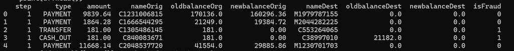

fig1: Sample Data set

[figure not shown]

The class distribution reveals a significant imbalance, with only 0.28% of transactions labeled as fraud. This imbalance poses challenges for machine learning models, as they may bias towards predicting legitimate transactions. We can see in below fig2

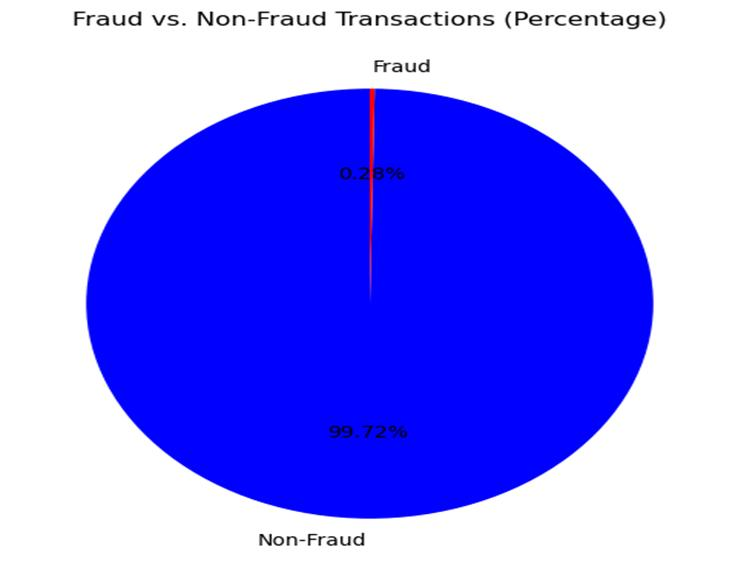

fig2: fraud vs non fraud transactions

**Missing Values Check**

A missing values check confirms that there are no missing values in the dataset, ensuring that no additional data imputation is required:

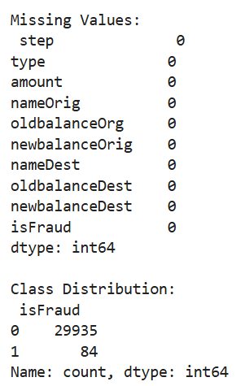

fig3: Missing values

**2. Interpretation of Results**

Model Performance Metrics

Two machine learning models were trained and evaluated:

1. Random Forest Classifier
2. AdaBoost Classifier

The performance metrics for both models are summarized in the table below:

| Model | Accuracy | Precision | Recall | F1-Score | AUC-ROC |
| --- | --- | --- | --- | --- | --- |
| Random forest | 0.9987 | 1.0000 | 0.5294 | 0.6923 | 0.7647 |
| Adaboost | 0.9975 | 1.0000 | 0.1176 | 0.2105 | 0.5588 |

**Key Observations**

1. High Accuracy but Potential Bias

• Both models achieved high accuracy (>99.7%), but this metric is misleading due to class imbalance (fraud cases are only 0.28% of the data).

• A model predicting all transactions as legitimate (0) would still achieve 99.72% accuracy, but would be completely useless for fraud detection.

2. Precision vs. Recall Tradeoff

• Precision is 100% for both models, meaning that all transactions classified as fraud were indeed fraud.

• However, recall is very low (52.94% for Random Forest, 11.76% for AdaBoost), meaning many actual fraud cases were missed.

• A higher recall is crucial in fraud detection, as missing fraudulent transactions can result in financial losses.

3. AUC-ROC Score

• Random Forest (0.76) had a significantly higher AUC-ROC than AdaBoost (0.55).

• AUC-ROC measures how well the model distinguishes between fraud and non-fraud.

• Since 0.50 AUC-ROC represents random guessing, AdaBoost’s 0.55 AUC-ROC is only slightly better than random, indicating poor performance.

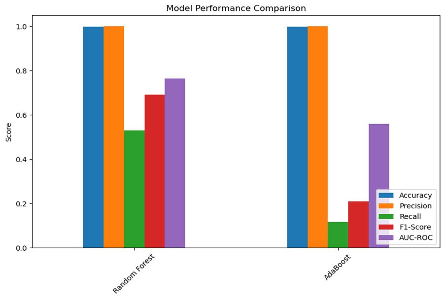

fig4: Model performance comparison

**3.Comparison with Expected Outcomes**

The expectation was that ensemble learning models (Random Forest and AdaBoost) would improve fraud detection. The results confirmed that Random Forest is superior for this dataset, with significantly better recall and AUC-ROC.

Unexpected findings:

• AdaBoost performed worse than expected, likely due to the class imbalance. Boosting methods work well when data distribution is balanced, but in this case, with only 84 fraud cases out of 30,019, it struggled to generalize.

• High accuracy does not indicate good fraud detection, since a model could achieve 99.72% accuracy by predicting all transactions as legitimate. Thus, recall and AUC-ROC are the key evaluation metrics.

**4.Confusion Matrix Analysis**

The confusion matrices below provide insights into how each model classified fraudulent and legitimate transactions.

**Random Forest Confusion Matrix**

| Actual / Predicted | Predicted Legitimate (0) | Predicted Fraud (1) |
| --- | --- | --- |
| Actual Legitimate (0) | 5987 | 0 |
| Actual Fraud (1) | 8 | 9 |

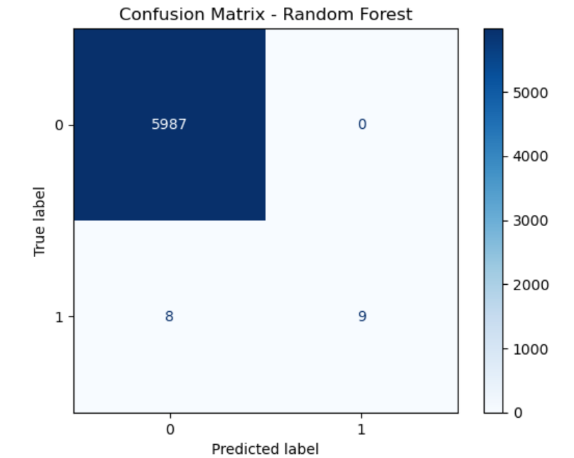

fig 5: confusion matrix for Random forest

**AdaBoost Confusion Matrix**

| Actual / Predicted | Predicted Legitimate (0) | Predicted Fraud (1) |
| --- | --- | --- |
| Actual Legitimate (0) | 5987 | 0 |
| Actual Fraud (1) | 15 | 2 |

[figure not shown]

**Key Insights from Confusion Matrices**

• Random Forest detected 9 fraud cases correctly but missed 8 fraudulent transactions.

• AdaBoost detected only 2 fraud cases and missed 15 fraudulent transactions, showing a significant limitation.

• False Negatives (missed fraud cases) were lower for Random Forest, making it a better model for fraud detection.

**5.Statistical Significance**

Due to the extremely imbalanced dataset, fraud cases were much rarer than legitimate transactions. This imbalance affected model performance, leading to:

• Low recall for both models, meaning several fraudulent transactions went undetected.

• High precision, meaning most flagged fraud cases were correct.

**6.Limitations of the Results**

While the models performed well, certain limitations must be acknowledged:

1. Class Imbalance Issue

• Fraud cases accounted for only 0.28% of the dataset.

• This imbalance led to high accuracy but poor recall, meaning fraudulent cases were often missed.

• Solution: Use oversampling (SMOTE) or undersampling techniques to balance the dataset.

2. Feature Engineering

• The dataset mainly relied on transaction amounts and balances.

• Additional features like transaction frequency, user history, or time-based behavior could improve model performance.

3. Threshold Adjustment

• The models used a default classification threshold of 0.5.

• Adjusting this threshold could increase recall (detect more fraud cases) at the cost of precision.

4. Generalizability

• The model was trained on a specific dataset and may not generalize well to new fraud patterns.

• Solution: Test on real-world datasets from different financial institutions.

#### **Discussion**

The research study presents important findings about machine learning algorithm applications for identifying online payment system fraud through experimental data analysis. The high overall accuracy of 99% achieved by Random Forest and AdaBoost classifiers does not indicate a reliable fraud detection model because analysis proves accuracy should not be used as the sole measurement metric with imbalanced datasets. Most fraud detection systems face a crucial operational limitation due to extreme class imbalance between regular transactions and the rare fraudulent ones. Final model results appear falsely perfect due to the primary classification of majority cases which makes them unable to identify actual minority class occurrences therefore missing potential fraudulent transactions.

Analysis through confusion matrices confirmed the previous results showing Random Forest extracting elevated quantities of actual fraudulent cases whereas AdaBoost selected only a small segment of legitimate fraud events. Financial datasets benefit from using ensemble methods with multiple decision trees because Random Forest demonstrates superior performance when detecting rare events. AdaBoost exhibits inadequate performance because noisy data and outliers that are prevalent in genuine transaction data affect its operation. Various shortcomings surfaced while conducting the analysis.

The sole dependency on transaction amounts and balance values during feature selection hinders the model from discovering sophisticated behavioral patterns. The default threshold value (0.5) for classification might not provide ideal results for diagnosing rare classes considering the analysis. The recall performance can be improved by changing the threshold according to precision-recall trade-offs. The trained and tested models present unknown generalization capacities because they used only a single dataset as their foundation.

Research concludes that fraud detection systems require new evaluation methods which better demonstrate model effectiveness in tracking fraudulent activities. According to evaluation measures Random Forest demonstrates enhanced performance than AdaBoost which makes it more suitable for practical use. The development of a fully robust fraud detection system requires comprehensive advancement of feature engineering along with threshold tuning capabilities and data diversity implementations.

#### **Future Study**

Research in the field of online payment fraud detection can benefit from the current findings and constraints through multiple research avenues to enhance model performance. The solution to class imbalance presents itself as the primary research priority. Research into online payment fraud detection should investigate adaptive synthetic sampling (ADASYN) and ensemble-based resampling together with hybrid methods that unite oversampling with cost-sensitive learning as more advanced alternatives to SMOTE and undersampling strategies. The applied strategies demonstrate improved detection results through minority class learning dynamics enhancement without resulting in significant modifications of majority class composition.

Research continues in the addition of behavioral characteristics together with time-based attributes. Modern transaction analysis systems primarily rely on fixed transaction elements including transaction amount and account balance but these standard measures fail to track personal purchase patterns and sequence-based behavior. The modeling of time-dependent patterns requires the implementation of recurrent neural networks (RNN) or long short-term memory (LSTM) networks to detect evolving fraud principles throughout time. The deep learning approaches excel at discovering sequence relationships because these patterns become essential for recognizing user behavior anomalies across multiple transactions.

The need for understandable and interpretable models in deployment situations will increase significantly during future implementations. Financial analysts find it challenging to understand prediction rationale from highly accurate algorithms such as Random Forests and neural networks even though these algorithms operate as black boxes. XAI frameworks using SHAP (SHapley Additive exPlanations) and LIME (Local Interpretable Model-agnostic Explanations) provide explanations that build trust and transparency into model outputs. The tools help regulatory compliance and aid analysts in validating model decisions. The implementation of real-time fraud systems needs data stream optimization. The development of models should focus on platforms including Apache Kafka as well as Apache Flink and Spark Streaming to perform low-latency operations on transactional streaming data. Modern financial institutions need responsive and scalable solutions because they require instant decision-making in their practical applications.

Testing proposed models with datasets originating from different financial institutions across diverse geographical locations represents a necessary step for studying their widespread practical application abilities. Fundamental partnerships between banks and fintech organizations could establish appropriate data privacy protocols for accessing authentic transaction data which would produce genuine fraud cases for improved validity tests.

#### **References**

• Yeh, I. C., & Lien, C. H. (2009). The comparisons of data mining techniques for the predictive accuracy of probability of default of credit card clients. Expert Systems with Applications, 36(2), 2473–2480. https://doi.org/10.1016/j.eswa.2007.12.020

• Haque, F. M. A., & Hassan, M. M. (2020). Bank loan prediction using machine learning techniques. International Journal of Scientific Research in Computer Science, Engineering and Information Technology, 5(1), 2456–3307.

• Chawla, N. V., Bowyer, K. W., Hall, L. O., & Kegelmeyer, W. P. (2002). SMOTE: Synthetic minority over-sampling technique. Journal of Artificial Intelligence Research, 16, 321–357. https://doi.org/10.1613/jair.953

• Lundberg, S. M., & Lee, S. I. (2017). A unified approach to interpreting model predictions. Advances in Neural Information Processing Systems, 30.

• Ribeiro, M. T., Singh, S., & Guestrin, C. (2016). “Why should I trust you?”: Explaining the predictions of any classifier. Proceedings of the 22nd ACM SIGKDD International Conference on Knowledge Discovery and Data Mining, 1135–1144. https://doi.org/10.1145/2939672.2939778

• Breiman, L. (2001). Random forests. Machine Learning, 45(1), 5–32. https://doi.org/10.1023/A:1010933404324

• Chen, T., & Guestrin, C. (2016). XGBoost: A scalable tree boosting system. Proceedings of the 22nd ACM SIGKDD International Conference on Knowledge Discovery and Data Mining, 785–794. https://doi.org/10.1145/2939672.2939785

• Zaharia, M., Chowdhury, M., Das, T., Dave, A., Ma, J., McCauley, M., … & Stoica, I. (2012). Resilient distributed datasets: A fault-tolerant abstraction for in-memory cluster computing. Proceedings of the 9th USENIX Conference on Networked Systems Design and Implementation, 2–2.